# When Gender Matters

Party Differences in Female Candidate Success in Primary Elections

Audrey Loritz

## Introduction

**How does gender impact candidate success in primary elections for the different political parties?**

Gender has long been considered an important factor in electoral politics, particularly in recent decades as the number of female candidates has increased across party lines. By narrowing in on primary elections, it is possible to examine gendered differences in primary success both within and between the Democratic and Republican parties. Understanding this relationship is important as it sheds light on whether barriers or advantages exist for women and whether these patterns differ across partisan contexts.

I hypothesize that the effect of gender on candidate success will differ by party. Specifically, I expect that female candidates will perform better in Democratic primaries than in Republican primaries, where gender will have negative effects for female candidates. This assumption stems from the idea that Democratic electorates tend to be more supportive of female candidates, while Republican electorates may be less responsive to gender as an advantage. As a result, gender is likely to have a conditional effect on electoral success rather than a uniform one across parties.

## Data

The data used in this analysis comes from a combined dataset of Democratic and Republican results from the 2022 primary elections. The predictor variables used are party, determined by which primary the candidate is running in, and gender, determined by the candidate’s campaign materials. The outcome variable is primary election success, which is measured by the percentage of votes a candidate got during the initial 2022 primary election, not examining run off elections. The following analysis uses a cross-sectional observational design, comparing candidates at a single point in time rather than tracking changes over time.

The graph below displays the distribution of primary election vote share, the main outcome of interest. Additionally, it indicates the different distribution of male and female vote shares to illustrate how that variation of interest looks.

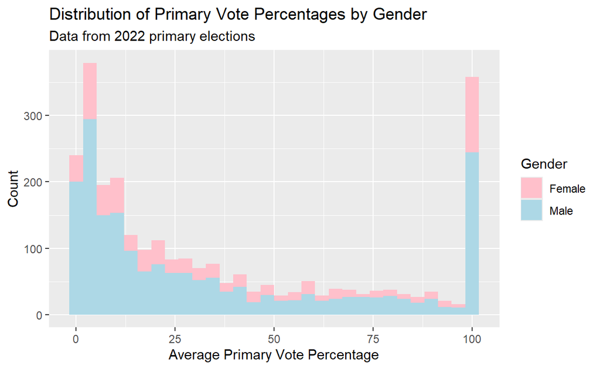

For this paper, there are two comparisons of interest: the difference between male and female candidates within each party, and the difference in effect gender has on the Democratic and Republican parties. To examine this, I will utilize the two hypotheses listed below.

**Party Hypothesis**

*Null Hypothesis:* Gender will have no impact on primary election results within each party.

*Alternative Hypothesis:* Gender impacts primary election success within each party.

Using α = 0.05, the null hypothesis can be rejected if the p-value of both the Democratic Party and Republican Party are less than 0.05. This would indicate that gender does affect primary election results, even if that effect varies across party lines in terms of advantage or disadvantage.

**Interaction Hypothesis**

*Null Hypothesis:* The effect of gender on primary election success will not vary by political party.

*Alternative Hypothesis:* The effect of gender on primary election success will vary by political party.

Using α = 0.05, the null hypothesis can be rejected if the p-value of the interaction coefficient is less than 0.05. This would indicate that there is a difference between the role that gender plays in Democratic and Republican primary elections.

## Results

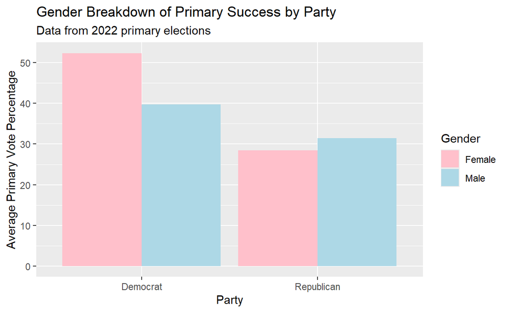

**Regression**

| Male Republicans | Gender Difference | Party Difference | Interaction Coefficient |
| --- | --- | --- | --- |
| 31.39 | -2.97 | 8.3 | 15.59 |

**Standard Errors**

| Male Republicans | Gender Difference | Party Difference | Interaction Coefficient |
| --- | --- | --- | --- |
| 0.97 | 2.11 | 1.62 | 3.05 |

**P-Values**

| Male Republicans | Gender Difference | Party Difference | Interaction Coefficient |
| --- | --- | --- | --- |
| 0 | 0.16 | 0 | 0 |

*Using the standard errors and p-values, it can be concluded that only the interaction hypothesis is statistically significant under α = 0.05.*

The standard errors reflect how much each estimate is expected to vary from the true population value due to sampling variability. The relatively small standard error for male Republicans, at 0.97, suggests that this estimate is likely close to the true population mean. The gender difference among Republicans, at 2.11, and the party difference among men, at 1.62, show more potential deviation from their true values. The interaction coefficient has the largest standard error, at 3.05, meaning this estimate may vary the most from the true population effect, indicating greater uncertainty in the estimate of how gender differences change across parties.

The gender hypothesis can not be rejected because the p-value for the difference between male and female Republicans is greater than the 0.05 level. This means that there is not sufficient information to reject the null hypothesis and prove that the observed difference between the genders was not due to chance alone. The interaction coefficient style of regression analysis does not provide a p-value test for the difference between male and female Democrats, but the “Party Difference” category suggests that there is a difference in the way that male Democrats and Republicans perform. Using this information, a difference in performance between males and females within the Democratic Party cannot be outruled without further hypothesis testing.

Despite this, the interaction hypothesis can still be proven because the p-value for the interaction coefficient is less than 0.05, Indicating that the interaction null hypothesis can be rejected. Suggesting with statistical significance that there is a difference in the effect of gender on primary election success between Democrats and Republicans, and the results found from the regression were likely not due to chance alone. While there is statistical significance, this relationship can not be deemed causal. Since the data comes from an observational study rather than a randomly assigned experiment, it is possible that the outcome stems from a missed confounding variable. The nature of this analysis does account for one possible confounding variable, party, however there are still other variables that could be affecting the results. Factors such as incumbency, district competitiveness, and geographic location could all impact the relationship between gender and party. Without controlling for these potential confounders or using a causal research design, the results can only demonstrate correlation, not causation.

## Conclusion

The hypothesis that the effect of gender on primary election results varies between political parties is strongly supported. However, several limitations need to be considered, most notably, the possibility of confounding variables, stemming from the observational nature of the data. In particular, the fact that candidates were not randomly assigned could result in unintended confounders, such as incumbency status. The Democratic Party had a higher proportion of women incumbents leading up to the 2022 primaries, and incumbents are known to have an electoral advantage, which could partially explain the observed success of female Democratic candidates. While it is not possible to randomly assign the treatment of gender, this analysis could be improved by accounting for possible confounders, like incumbency status, to further isolate the independent effect of gender on election outcomes.

## Code

```r
library(tidyverse)
library(broom)
library(infer)

dem_candidates <- read_csv("data/dem_candidates.csv")
rep_candidates <- read_csv("data/rep_candidates.csv")

elections <- bind_rows(dem_candidates, rep_candidates,
                       .id = "Party")

elections <- elections |>
  select(Candidate, Party, Gender, `Race 1`, Office, `Primary Outcome`, `Primary %`, `Runoff Outcome`, `Runoff %`) |>
   mutate(Party = if_else(Party == 1, "Democrat", "Republican"))

elections <- elections |>
  mutate(`Primary %` = parse_number(`Primary %`)) |>
  filter(Gender != "Nonbinary")

interest <- ggplot(elections, aes(x = `Primary %`, fill = Gender)) +
  geom_histogram() +
  scale_fill_manual(values = c("Female" = "pink", "Male" = "lightblue")) +
  labs(x = "Average Primary Vote Percentage", y = "Count",
       title = "Distribution of Primary Vote Percentages by Gender",
       subtitle = "Data from 2022 primary elections")

interest

party_gender_success <- elections |> group_by(Party, Gender) |>
           summarise(avg_primary = mean(`Primary %`, na.rm = TRUE)) |>
  ggplot(aes(x = Party, y = avg_primary, fill = Gender)) +
  geom_col(position = "dodge") +
  scale_fill_manual(values = c("Female" = "pink", "Male" = "lightblue")) +
  labs(x = "Party", y = "Average Primary Vote Percentage",
       title = "Gender Breakdown of Primary Success by Party",
       subtitle = "Data from 2022 primary elections")

party_gender_success

fit <- lm(`Primary %` ~
            relevel(as.factor(Gender), ref = "Male") *
            relevel(as.factor(Party), ref = "Republican"),
          data = elections)

fit_table <- tidy(fit) |>
  select(term, estimate) |>
  pivot_wider(names_from = term, values_from = estimate)

knitr::kable(fit_table, digits = 2,
             col.names = c("Male Republicans", "Gender Difference",
                           "Party Difference", "Interaction Coefficient"))

std_er <- tidy(fit) |>
  select(term, std.error) |>
  pivot_wider(names_from = term, values_from = std.error)

knitr::kable(std_er, digits = 2,
             col.names = c("Male Republicans", "Gender Difference",
                           "Party Difference", "Interaction Coefficient"))

p_values <- tidy(fit) |>
  select(term, p.value) |>
  pivot_wider(names_from = term, values_from = p.value)

knitr::kable(p_values, digits = 2,
             col.names = c("Male Republicans", "Gender Difference",
                           "Party Difference", "Interaction Coefficient"))
```